# Consultancy Report - Core Visualizations (Draft)

# 1 1. Scope And Baseline Strategy

This report is structured around the three decision questions in Brief 6.  
The primary effect-size baseline is a 30-year comparison of 1961-1990 versus 1991-2020.  
Long-run context uses the full comparable period for mean, min, and max from 1879 to 2024.  
This setup lets us quantify recent shift size while still separating long-run change from short-term seasonal noise.

# 2 2. Decision 1: Is There A Sustained Shift And How Large Is It

## 2.1 Figure 3: 30-Year Baseline Shift

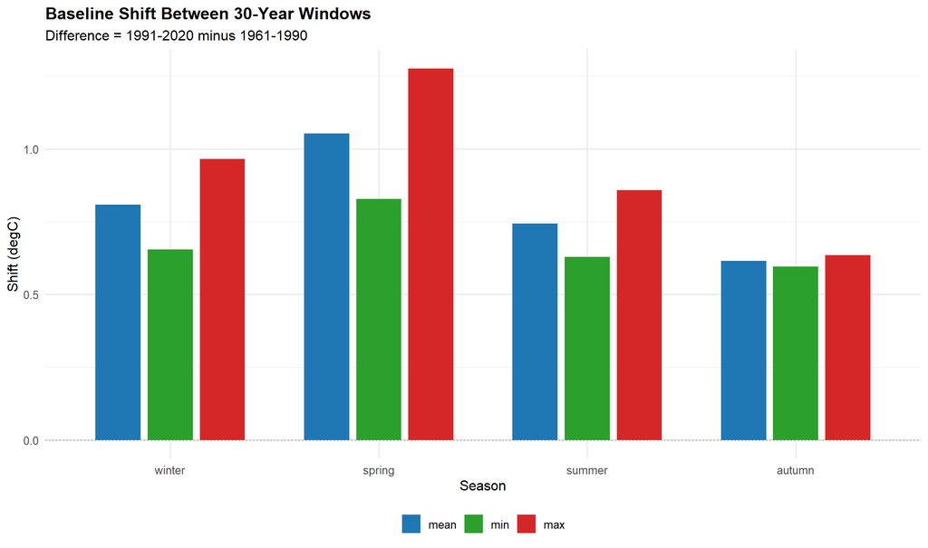

```r
p3 <- make_figure_3(
  save_plot = TRUE,
  historical_start = 1961, historical_end = 1990,
  recent_start = 1991, recent_end = 2020
)
p3
```

Reading note.  
This is the easiest before-versus-after chart.  
Each bar equals recent 30 years minus earlier 30 years.  
Bars above zero mean warmer recent conditions.  
Taller bars mean a bigger shift.

Interpretation.  
All shifts are positive for 1991-2020 minus 1961-1990.  
Values range from +0.596 to +1.276 degC across season and metric pairs.  
The largest mean shift is in spring (+1.052 degC), followed by winter (+0.808), summer (+0.744), and autumn (+0.615).  
Spring maximum is also the largest maximum shift (+1.276 degC).  
Mean, minimum, and maximum all move in the same direction, which supports a robust warming signal.

## 2.2 Figure 2: Rolling Mean Anomaly

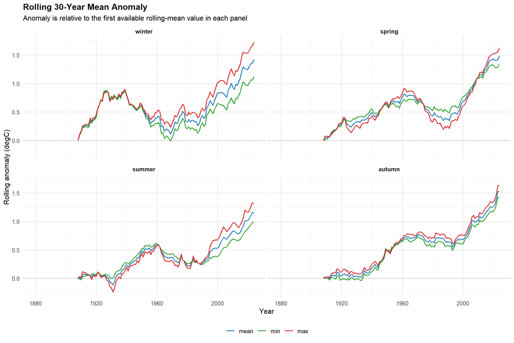

```r
p2 <- make_figure_2(save_plot = TRUE, window = 30)
p2
```

Reading note.  
Think of this as a long-memory warming signal. The dashed zero line is the old climate reference.  
If a line stays above zero for many years, the warming shift is persistent.

Interpretation.  
By 2024, all season and metric combinations are positive relative to their early rolling baseline.  
The largest end-of-series anomalies are winter max (+1.726 degC), autumn max (+1.634 degC), and spring max (+1.622 degC).  
Summer min is also clearly positive (+0.977 degC).  
This shows that warming is sustained over decades rather than driven by isolated years.

# 3 3. Decision 2: Which Seasons Change Most And What Type Of Change Is It

## 3.1 Figure 1: Seasonal Trajectories

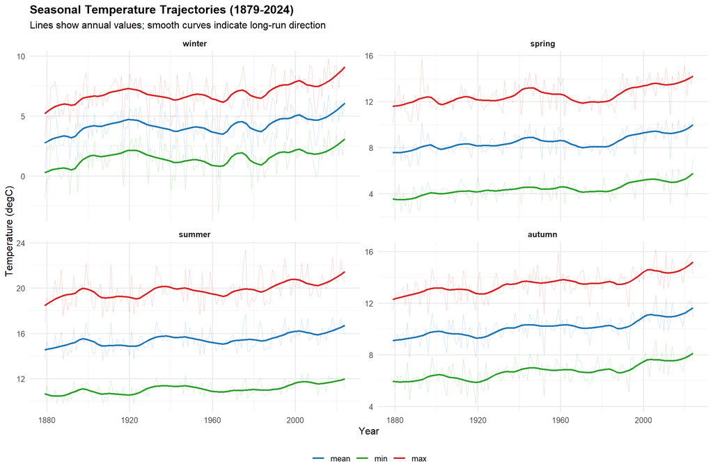

```r
p1 <- make_figure_1(save_plot = TRUE)
p1
```

Reading note.  
Each panel is one season.  
Faint lines are noisy year-to-year movement.  
Smooth lines show the underlying direction.  
If smooth lines keep rising from left to right, that season is warming in a structural way.

## 3.2 Figure 4: Warming Rate Per Decade

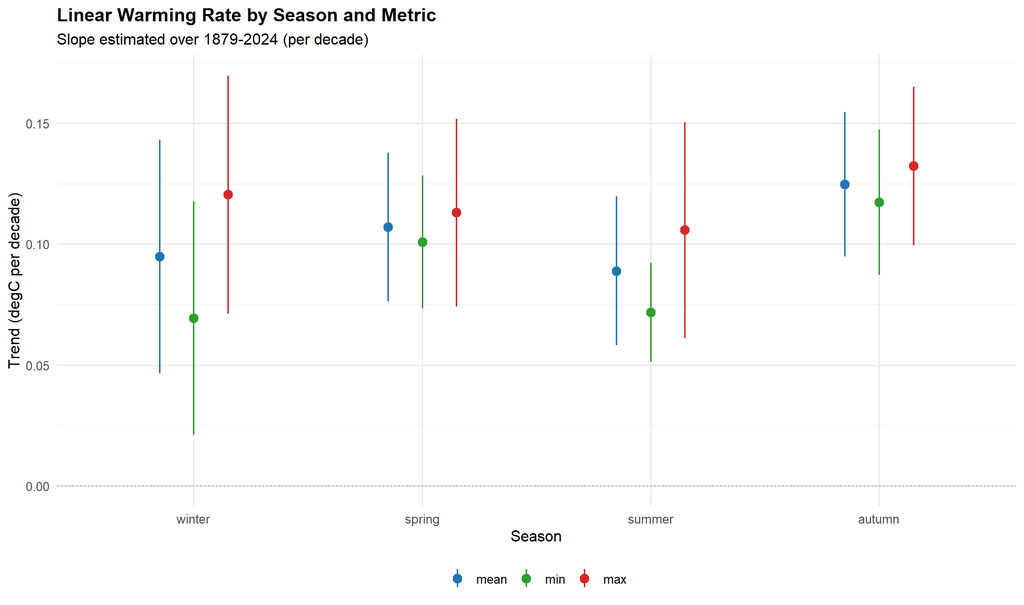

```r
p4 <- make_figure_4(save_plot = TRUE, year_min = 1879, year_max = 2024)
p4
```

Reading note.  
Each point is warming speed per decade.  
Higher points mean faster warming.  
The vertical line around each point is uncertainty.  
If the full line stays above zero, warming is statistically clear.

Interpretation.  
Estimated trends are positive in all 12 season and metric combinations, from +0.069 to +0.132 degC per decade.  
The 95% confidence intervals are above zero for every estimate, for example autumn max +0.132 [0.099, 0.165] and winter min +0.069 [0.021, 0.118].  
Maximum temperature trends are generally steeper than minimum temperature trends, especially in winter and summer.

## 3.3 Figure 5: Rolling Variability

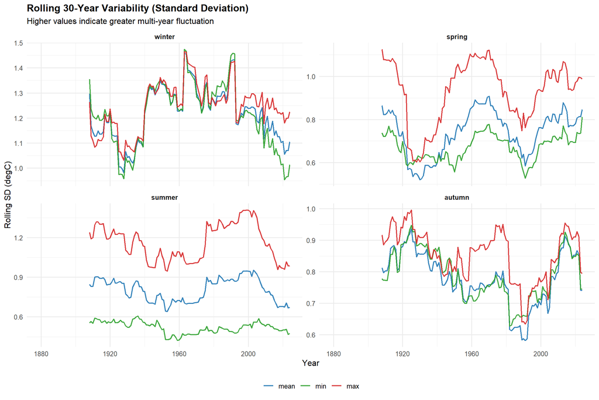

```r
p5 <- make_figure_5(save_plot = TRUE, window = 30)
p5
```

Reading note.  
This figure is about wobble, not average level.  
It tracks rolling 30-year standard deviation.  
Rising lines mean bigger year-to-year swings.  
Falling lines mean calmer variation.

Interpretation.  
Variability changes are season dependent rather than uniform.  
Comparing 1991-2020 with 1961-1990, spring and autumn variability rise across metrics, with SD increases of roughly +0.136 to +0.267.  
Winter and summer mostly decline or stay flat, for example winter min -0.432, summer max -0.356, and summer min +0.008.  
This means level shift and volatility shift are not the same pattern.

# 4 4. Decision 3: Monitoring And Communication

## 4.1 Figure 6: Distribution Shift By Period

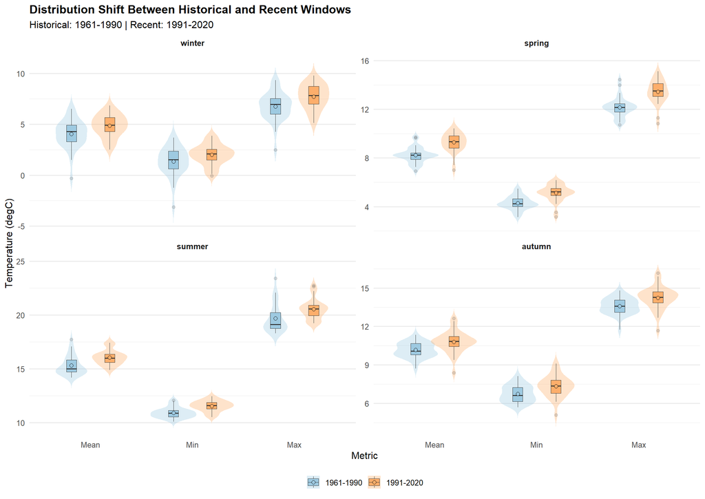

```r
p6 <- make_figure_6(
  save_plot = TRUE,
  historical_start = 1961, historical_end = 1990,
  recent_start = 1991, recent_end = 2020
)
p6
```

Reading note.  
This compares full temperature shapes, not only averages.  
If the recent box and violin sit higher, typical conditions are warmer.  
If the shape is wider, spread is larger.  
This helps when deciding what to monitor beyond the mean.

Interpretation.  
Recent distributions shift upward relative to 1961-1990 in every season and metric, with median increases from +0.575 to +1.445 degC.  
The largest median shifts occur in summer max (+1.445), spring max (+1.355), and spring mean (+1.115).  
Spread changes are mixed by season.  
Several winter and summer series narrow, while spring and autumn widen.  
Monitoring should track both central level and season-specific spread.

# 5 5. Alignment With Brief 6

Current sections already address the core brief requirements.  
Decision 1 is covered by 30-year baseline shifts and persistence diagnostics.  
Decision 2 is covered by seasonal trend strength and variability behavior.  
Decision 3 is covered by distributional evidence for reporting priorities.  
To fully complete the brief, add a formal robustness section with alternative baseline windows and start-end sensitivity checks.